Skip to main content

# MULTIFAN-CL to opal: south-west Pacific albacore

Bridging the 2024 WCPFC south Pacific albacore diagnostic model, a two-region MULTIFAN-CL model, to a single-region opal model

Author

Nicholas Ducharme-Barth

Published

November 5, 2026

**Setup: read the caches**

```r
# Code is shown (folded) in the HTML version and hidden in the PDF.
knitr::opts_chunk$set(echo = knitr::is_html_output())
library(data.table)
library(ggplot2)
library(patchwork)

bridge = readRDS(file.path("data", "swpo-alb-mfcl-bridge.rds"))
oc     = readRDS(file.path("data", "swpo-alb-opal-cache.rds"))
lfd    = readRDS(file.path("data", "swpo-alb-lf-diagnostics.rds"))
sel    = readRDS(file.path("data", "swpo-alb-opal-sel-fits.rds"))
sdg    = readRDS(file.path("data", "swpo-alb-sel-diagnostics.rds"))
lft    = readRDS(file.path("data", "swpo-alb-lf-tests.rds"))
asel   = readRDS(file.path("data", "swpo-alb-age-sel-fits.rds"))
hyb    = readRDS(file.path("data", "swpo-alb-hybrid-fits.rds"))

theme_set(theme_bw(base_size = 11) +
          theme(legend.position = "bottom", panel.grid.minor = element_blank()))
fmt = function(x, d = 2) ifelse(is.na(x), "", formatC(x, format = "f", digits = d, big.mark = ","))
sci = function(x, d = 1) formatC(x, format = "e", digits = d)
pct = function(x, d = 1) paste0(fmt(100 * x, d), "%")
# Pipe table with relative column widths (dash counts), for wide text tables
pipe_table = function(x, widths) {
    x = as.data.frame(x)
    row = function(v) paste0("| ", paste(gsub("\\|", "/", v), collapse = " | "), " |")
    cat(row(names(x)), paste0("|", paste0(":", strrep("-", widths), collapse = "|"), "|"),
        apply(x, 1, row), sep = "\n")
}

L  = bridge$likelihood
TS = bridge$timeseries
TR = oc$trajectory
RP = oc$replays
PR = oc$profile
P  = lfd$profiles
lb_mfcl = oc$log_B0_mfcl
# One colour per model in every figure: MFCL in black, the bridge steps in
# browns, O0 purple, fits with MFCL's selectivity (O1 family) blue,
# length-based double normals (O2 family) orange-red, age-based and hybrid
# (O3/O4 family) green; quarterly-age models dashed in their family's colour.
# The profile set-ups take the colour of the fit with the same set-up.
model_col = c(MFCL = "black", `MFCL M3` = "black", M3 = "black",
              M0 = "grey60", M1 = "#B9770E", M1b = "#F0B27A", M2 = "#6E2C00",
              O0 = "#7D3C98",
              O1 = "#85C1E9", `O1-mid` = "#2E86C1", O1i = "#138D75", O1q = "#5DADE2",
              O2 = "#E67E22", `O2-split` = "#F5B041", `O2-all` = "#C0392B", O2q = "#E67E22",
              O3 = "#82E0AA", O4 = "#28B463", `O4-fix` = "#145A32", `O4q-fix` = "#28B463",
              annual = "#85C1E9", `annual-mid` = "#2E86C1", quarterly = "#5DADE2",
              split = "#F06292", `split-mid` = "#AD1457")
model_lty = setNames(ifelse(grepl("q|quarterly", names(model_col)), "22", "solid"), names(model_col))
scale_models = function() list(scale_colour_manual(values = model_col, breaks = names(model_col)),
                               scale_linetype_manual(values = model_lty, breaks = names(model_col)))
# All spawning-biomass trajectories in one table (depletion against opal's
# unfished projection, MFCL's against its own)
ALL = unique(rbindlist(list(
    TR[, .(model, year, sb, depletion = dynamic_depletion)],
    sel$trajectory[, .(model, year, sb, depletion = dynamic_depletion)],
    lft$trajectory[, .(model, year, sb, depletion)],
    asel$trajectory[, .(model, year, sb, depletion)],
    hyb$trajectory[, .(model, year, sb, depletion)])), by = c("model", "year"))
sb_at = function(s, y) TS[step == s & year == y, sb]
dep_at = function(s, y) TS[step == s & year == y, depletion]
o1_lb = oc$o1$par[["log_B0"]]
o1m_lb = oc$o1_mid$par[["log_B0"]]
```

# 1 Overview

This document converts the 2024 stock assessment of south Pacific albacore (*Thunnus alalunga*) (Teears et al. 2024), a two-region MULTIFAN-CL (MFCL, Fournier et al. 1998; Davies et al. 2025) model, into opal, an RTMB age-structured model with one region. Any model runs here are preliminary explorations and should not be used *as is* for management advice. opal is not changed: where it cannot represent the MFCL model, the MFCL model is simplified (in MFCL) or the difference is measured with replays (standalone simulations) and documented. The comparisons are meant as advice to opal’s developers on the features the stock would need.

# 2 The 2024 assessment

The assessment (Teears et al. 2024) covers the south Pacific from the equator to 50°S and from 140°E to the coast of South America, in two regions: region 1 is the southern WCPFC Convention Area, including the overlap area with the EPO, and region 2 the rest of the EPO. Fisheries are defined as areas-as-fleets within each region (six areas in region 1, three in region 2).

- **Time.** 1954 to the third quarter of 2022. The model year runs October-September with recruitment on 1 October (week 37 of the calendar year in the report), 12 annual age classes (the last a plus group); catches are taken by quarter (longline, driftnet) or month (troll).
- **Fisheries.** 17 extraction fisheries (13 in region 1: longline by flag group and area, two troll fisheries and a driftnet fishery; 4 in region 2) and three index fisheries (region 1: longline north of 25°S and New Zealand troll; region 2: longline). Catches are in numbers except troll and driftnet (weight). The catch-conditioned approach solves the Baranov catch equation for fishing mortality at each fishing incident.
- **Indices.** sdmTMB standardised CPUE (Anderson et al. 2022) with time-varying CVs; the troll index’s generic CV is set to 0.2.
- **Length compositions.** 50 2-cm bins from 30 cm, re-weighted by catch; robust normal likelihood; sample sizes capped at 1000 and divided by Francis (2011) weights; samples below 50 fish dropped.
- **Conditional age-at-length.** 654 otolith ages in 33 fishery-quarter strata, effective sample size 0.75 of the observed.
- **Biology.** von Bertalanffy growth with offsets at ages 2-4 (L<sub>1</sub> fixed at 45.5 cm); M-at-age inversely proportional to length (Lorenzen 1996), scaled to average 0.36 over ages 4-12; spawning potential from maturity and sex ratio at length; Beverton-Holt steepness 0.8 with a weak penalty (CV 0.71) on recruitment deviations; fixed recruitment distribution (0.819 in region 1) and movement from SEAPODYM (Senina et al. 2020).
- **Selectivity.** Length-based cubic splines (3-4 nodes), grouped across fisheries (16 groups), seasonal (four seasons) for the tropical longline fisheries 1-7 and the EPO fishery 14, non-decreasing for the longline indices.

The assessment found the stock not overfished and not subject to overfishing (median SB<sub>recent</sub>/SB<sub>F=0</sub> 0.48 across the model ensemble, including estimation uncertainty).

# 3 The MFCL bridge

```r
B = merge(L, TS[year == min(year), .(step, sb_1954 = sb / 1000)], by = "step")
B = merge(B, TS[year == max(year), .(step, sb_2022 = sb / 1000, depletion)], by = "step")
knitr::kable(B[, .(step, objective = fmt(objective, 1),
                   length = fmt(length_comp, 1), `age-length` = fmt(age_length, 1),
                   CPUE = fmt(cpue, 1), `max grad.` = sci(max_gradient),
                   `SB 1954` = fmt(sb_1954, 0), `SB 2022` = fmt(sb_2022, 0),
                   depletion = fmt(depletion, 3))], format = "pipe")
```

Table 1: The MFCL bridge (M0 diagnostic, M1 no movement, M1b movement weeks on fishing dates, M2 region 1 only, M3 growth fixed without age-at-length). Objective (negative log-likelihood plus penalties) and its components; region 1 spawning (adult) biomass in thousand tonnes; depletion in 2022 against the unfished projection (none for M1b, whose zero-fishing projection MFCL stops). M0-M1b’s region 1 values are from two-region models.

| step | objective | length | age-length | CPUE | max grad. | SB 1954 | SB 2022 | depletion |
| --- | --- | --- | --- | --- | --- | --- | --- | --- |
| M0 | -41,824.6 | -42,457.3 | 786.4 | -170.0 | 5.5e-07 | 871 | 251 | 0.502 |
| M1 | -41,813.2 | -42,455.2 | 788.3 | -162.3 | 3.3e-06 | 1,716 | 375 | 0.567 |
| M1b | -41,815.2 | -42,455.9 | 787.8 | -163.3 | 1.3e-06 | 1,692 | 363 |  |
| M2 | -36,315.1 | -37,009.1 | 792.2 | -111.8 | 5.1e-07 | 3,413 | 460 | 0.617 |
| M3 | -37,149.1 | -37,052.2 |  | -112.7 | 1.5e-06 | 6,594 | 860 | 0.751 |

The diagnostic model was supplied with MFCL 2.2.7.0, which reproduces its objective function value exactly (M0). Each later step is refitted with the diagnostic model’s phase 9 settings (2200 evaluations), warm-started from the previous step; a fit takes 15-20 minutes. M1 and M3 stop at the evaluation limit with the line search stalled, at maximum gradients of a few times 10<sup>-6</sup>.

- **M1, no movement.** The (fixed, SEAPODYM-derived) movement matrices are set to the identity, so the regions are closed populations. They still share the recruitment deviations (total recruitment split 0.819 / 0.181) and the stock-recruitment relationship, so the EPO data still inform region 1’s recruitment.
- **M1b, movement weeks on fishing dates.** The movement weeks change from 37, 5, 17 and 29 (1 October and the first weeks of February, May and August) to 5, 17, 29 and 41 (February, May, August and November), all region 1 fishing dates. With no movement this changes nothing but MFCL’s time steps: it removes the extra period at the start of each year that MFCL adds at a movement week in a multi-region model, which a one-region model does not have (see the transplant check below), so that M1b-M2 changes only the regions. MFCL’s zero-fishing projection for M1b stops with a “sanity error” (the first period of a year is no longer a movement period), so M1b has no depletion; its fit converges.
- **M2, region 1 only.** The EPO fisheries (14-17) and EPO index (20) are dropped and the region 1 indices renumbered 14 and 15. The par file is built from M1b’s: fishery- and region-indexed values are subset, region 1’s recruitment is kept by shifting the total population scaling parameter by log(0.818971), and the sections shaped by regions, movement or catch records come from MFCL’s `-makepar` for the one-region files (all zero or structural in this model). M2 removes the recruitment link to the EPO.
- **M3, growth fixed, no age-at-length.** opal has no conditional age-at-length likelihood, so growth is fixed at M2’s estimates and the data dropped.

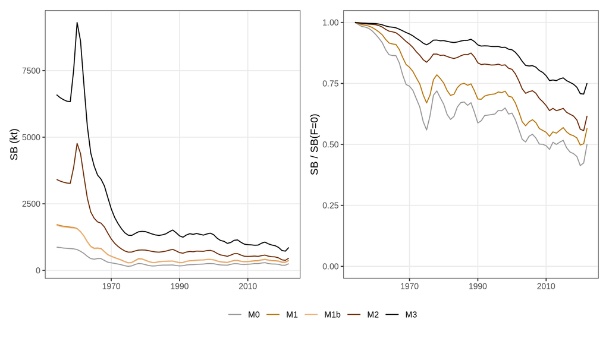

Figure 1: Region 1 spawning biomass and depletion along the MFCL bridge.

```r
p1 = ggplot(TS, aes(year, sb / 1e3, colour = step)) + geom_line() +
    scale_colour_manual(values = model_col) + labs(x = NULL, y = "SB (kt)", colour = NULL)
p2 = ggplot(TS, aes(year, depletion, colour = step)) + geom_line() +
    scale_colour_manual(values = model_col) + labs(x = NULL, y = "SB / SB(F=0)", colour = NULL) +
    coord_cartesian(ylim = c(0, 1))
p1 + p2 + plot_layout(guides = "collect")
```

Region 1’s spawning biomass in 1954 goes from 871 kt (M0) to 1,716, 3,413 and 6,594 kt, and depletion in 2022 from 0.50 to 0.75. In this catch-conditioned model the scale comes from the indices, the length compositions and their interaction with the catch; movement, the shared recruitment with the EPO and the age-at-length data each constrain it, and it drifts up as each is removed.

```r
knitr::kable(bridge$transplant_check[, .(quantity, `vs M1` = sci(vs_m1, 1), `vs M1b` = sci(vs_m1b, 1))], format = "pipe")
```

Table 2: Transplant checks: M2’s one-region structure evaluated (no refit) at M1’s and at M1b’s estimates against their region 1. Largest relative difference.

| quantity | vs M1 | vs M1b |
| --- | --- | --- |
| recruitment | 0.0e+00 | 0.0e+00 |
| numbers at age (1954) | 3.0e-03 | 3.0e-03 |
| numbers at age (all years) | 3.7e-02 | 3.0e-03 |
| adult biomass | 1.3e-02 | 1.5e-03 |
| predicted catch (extraction fisheries) | 0.0e+00 | 0.0e+00 |
| selectivity at age | 0.0e+00 | 0.0e+00 |
| mean length at age | 0.0e+00 | 0.0e+00 |
| natural mortality at age | 0.0e+00 | 0.0e+00 |

With no movement, region 1 in M1 is unaffected by region 2’s catch or abundance (tested by setting region 2’s catch and recruitment near zero), and M2’s inputs match its region 1 exactly: every `.frq` record (catch, effort, CV and length frequencies) and every flag and parameter section of the par file, with the total population scaling parameter shifted by exactly log(0.818971). Recruitment, selectivity, growth, M and the predicted catches agree, but against M1 the numbers at the oldest ages drift up by a few percent and adult biomass by up to 1.3%.

# 4 Conversion to opal

`shared/mfcl-to-opal/` reads MFCL’s `.par`, `.frq`, plot report and `length.fit` in base R and builds opal’s inputs (`mfcl_to_opal()`).

```r
F = oc$fisheries
knitr::kable(F[, .(fishery, `MFCL diagnostic` = mfcl_diagnostic, name, `catch units` = units,
                   `catch total` = fmt(catch_total, 0), seasons = sel_seasons,
                   divisor = lf_divisor, quarters = lf_quarters, years = lf_years)], format = "pipe")
```

Table 3: Fisheries in opal (M3). MFCL diagnostic: the fishery number in the two-region model. Seasons: distinct selectivity patterns by season in MFCL. Length data: the fish flag 49 divisor of the capped sample sizes, the number of quarters and of model years with compositions.

| fishery | MFCL diagnostic | name | catch units | catch total | seasons | divisor | quarters | years |
| --- | --- | --- | --- | --- | --- | --- | --- | --- |
| 1 | 1 | 1 LL DWFN 1a | numbers | 5,238,575 | 4 | 80 | 0 | 0 |
| 2 | 2 | 2 LL DWFN 1b | numbers | 14,751,211 | 4 | 183 | 0 | 0 |
| 3 | 3 | 3 LL DWFN 1c | numbers | 29,906,078 | 4 | 51 | 178 | 54 |
| 4 | 4 | 4 LL DWFN 1d | numbers | 21,609,922 | 4 | 164 | 145 | 49 |
| 5 | 5 | 5 LL PICT 1ab | numbers | 2,383,218 | 4 | 287 | 0 | 0 |
| 6 | 6 | 6 LL PICT 1ab | numbers | 31,848,058 | 4 | 89 | 116 | 31 |
| 7 | 7 | 7 LL AU/NZ 1ab | numbers | 535,380 | 4 | 29 | 25 | 13 |
| 8 | 8 | 8 LL DWFN 1cd | numbers | 56,708,825 | 1 | 372 | 89 | 42 |
| 9 | 9 | 9 LL PICT 1cd | numbers | 1,718,893 | 1 | 212 | 17 | 14 |
| 10 | 10 | 10 LL AU/NZ 1cd | numbers | 4,421,636 | 1 | 125 | 74 | 27 |
| 11 | 11 | 11 TR 1c | weight (t) | 108,687 | 1 | 27 | 74 | 25 |
| 12 | 12 | 12 TR 1d | weight (t) | 48,506 | 1 | 37 | 14 | 7 |
| 13 | 13 | 13 DN 1cd | weight (t) | 41,679 | 1 | 358 | 2 | 2 |
| 14 | 18 | 14 LL index 1abcd | numbers | 0 | 1 | 746 | 57 | 57 |
| 15 | 19 | 15 TR index 1ef | numbers | 0 | 1 | 55 | 25 | 25 |

- **Time.** MFCL’s model year starts in calendar month 10: the `.frq` dimension line’s ninth field (MFCL’s `month_1`), which the report gives as week 37. Calendar months 10-12 belong to the next model year (so the data’s last model year, 2022, has no calendar October-December). opal has 69 model years of four seasons (October-December, January-March, …), with recruitment and ageing at the start of the year. Fishing incidents in the same fishery and season are summed (troll catches are monthly).
- **Catch** is in numbers for the longline fisheries and in tonnes for troll and driftnet; the two indices remove nothing.
- **Indices.** MFCL’s survey likelihood is log-normal with variance $\lambda_i \sigma^2$, where $\lambda_i$ is the `.frq` CV column over its mean and $\sigma$ fish flag 92 / 100 (0.2): opal’s standard errors are $\sigma \sqrt{\lambda_i}$. Both indices are annual (longline in July-September, troll in January-March).
- **Length compositions.** Samples below 50 fish are dropped, each is rescaled to its sample size capped at 1000, and they are summed by fishery and model year, with MFCL’s divisors as opal’s variance adjustments, under opal’s multinomial likelihood (MFCL: robust normal per incident).
- **Biology.** Mean weight, maturity and M at age from MFCL’s report, so opal’s spawning biomass is MFCL’s adult biomass (numbers x weight x maturity at the start of the year). opal’s growth is used only for the length compositions: von Bertalanffy with age-specific K multipliers at ages 1-4 for MFCL’s independent mean lengths at ages 2-4 (RMSE 0.52 cm), SD linear in mean length between MFCL’s SDs at ages 1 and 12 (largest difference 0.47 cm).
- **Selectivity.** MFCL’s selectivity-at-age, averaged over seasons weighted by each season’s catch (index fisheries: their survey season), as opal’s `sel_fa_external`.

# 5 opal at MFCL’s values

O0 holds everything at MFCL M3’s values. `mfcl_match_recruitment()` sets opal’s B0 from MFCL’s Beverton-Holt curve ($R_0 = \alpha - \beta / \text{SPR}_0$, $B_0 = R_0 \text{SPR}_0$), its initial deviations so that opal starts from MFCL’s 1954 numbers-at-age, and its recruitment deviations (bias adjustment off) so that it recruits MFCL’s recruitment every year.

```r
knitr::kable(oc$o0_check[, .(quantity, `max rel. diff.` = sci(max_rel_diff, 1))], format = "pipe")
```

Table 4: O0 against MFCL M3: largest relative differences.

| quantity | max rel. diff. |
| --- | --- |
| numbers at age, first year | 4.8e-07 |
| recruitment | 2.0e-14 |

The replays are standalone simulations with MFCL’s estimates (not opal code). They cross catch removal at the start of each quarter, then a quarter of M (opal), or MFCL’s catch-conditioned Baranov in each fishing period (the year’s distinct incident dates, each with an equal share of the year’s M, as MFCL apportions it), with MFCL’s season-averaged selectivity (opal) or its seasonal selectivity.

```r
knitr::kable(RP[, .(`rel. 2022` = pct(rel_mfcl[.N], 2), `max |rel.|` = pct(max(abs(rel_mfcl)), 2),
                    `max |rel.| vs O0` = pct(max(abs(sb / opal_o0 - 1)), 2)),
                by = .(timing, selectivity)], format = "pipe")
```

Table 5: Replays: spawning biomass against MFCL M3 (relative difference in 2022 and largest annual) and against O0.

| timing | selectivity | rel. 2022 | max \|rel.\| | max \|rel.\| vs O0 |
| --- | --- | --- | --- | --- |
| opal | average | 1.58% | 2.12% | 0.06% |
| opal | seasonal | 1.62% | 2.18% | 0.19% |
| mfcl | average | -0.32% | 0.47% | 2.40% |
| mfcl | seasonal | -0.28% | 0.46% | 2.34% |

The opal-timing replay with averaged selectivity reproduces O0, which checks the replay. Catch timing accounts for almost all of the gap between O0 and MFCL; seasonal selectivity changes spawning biomass by less than 0.1%. The MFCL replay is within 0.5% of MFCL (0.6% with M shared by elapsed time instead); the remainder is largest in the mid-1990s, after the driftnet years, and may be the weight-at-age MFCL uses for catches in weight (not confirmed).

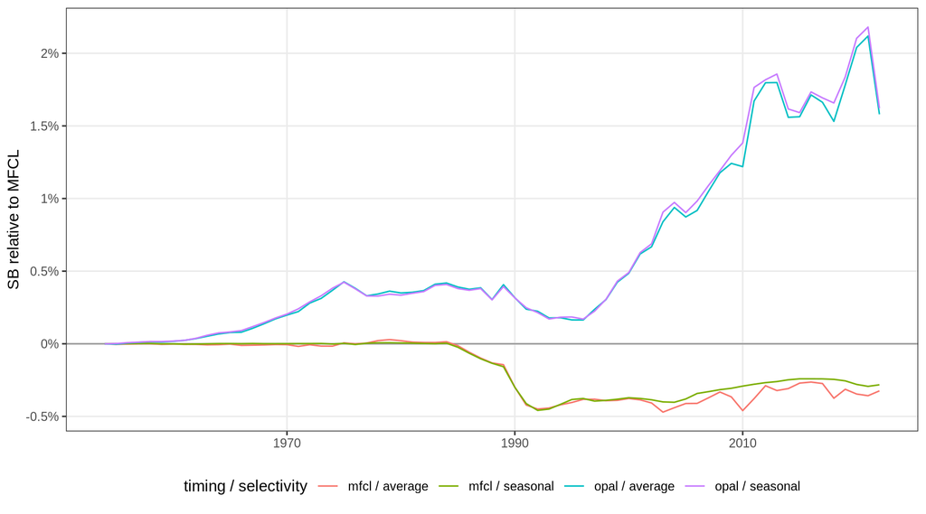

Figure 2: Spawning biomass relative to MFCL M3: O0 and the replays.

```r
ggplot(RP, aes(year, rel_mfcl, colour = paste(timing, selectivity, sep = " / "))) +
    geom_hline(yintercept = 0, colour = "grey60") + geom_line() +
    scale_y_continuous(labels = function(x) paste0(100 * x, "%")) +
    labs(x = NULL, y = "SB relative to MFCL", colour = "timing / selectivity")
```

# 6 opal fits

O1 holds MFCL’s season-averaged selectivity, growth, steepness (0.8), sigma<sub>R</sub> (0.64, MFCL’s CV of 0.71), M and the biology, and estimates B0, the recruitment deviations for 1955-2020 (the last two at the curve, as MFCL sets them at the mean), and the two index catchabilities. The initial population is unfished. Here and below, “MFCL’s scale” is MFCL’s Beverton-Holt B0 (log(B0) 14.04), the value O0 uses. O1 runs to the upper bound of log(B0) (22.00): spawning biomass in the billions of tonnes and depletion near 1.

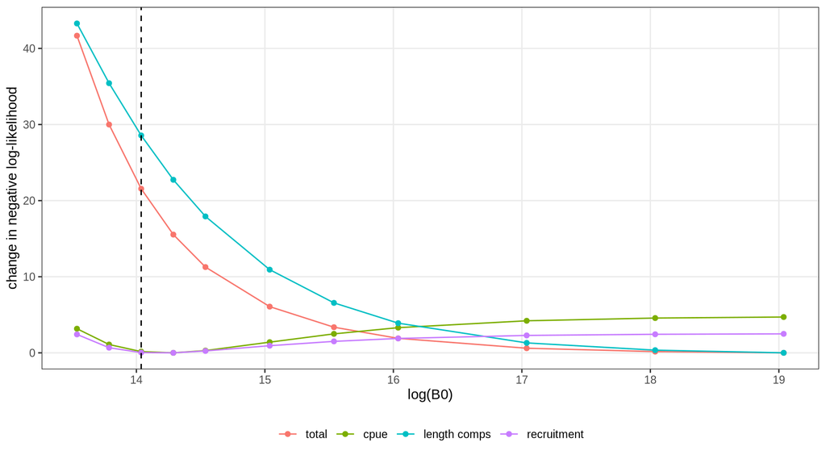

Figure 3: Profile over log(B0) for O1 (recruitment deviations and catchabilities estimated at each value): change in the objective and its components from their smallest values. The dashed line is MFCL’s scale.

```r
pr = melt(PR[, .(log_B0, total = objective, cpue, `length comps` = lf, recruitment = rec)],
          id.vars = "log_B0")
pr[, delta := value - min(value), by = variable]
ggplot(pr, aes(log_B0, delta, colour = variable)) + geom_line() + geom_point() +
    geom_vline(xintercept = lb_mfcl, linetype = 2) +
    labs(x = "log(B0)", y = "change in negative log-likelihood", colour = NULL)
```

The index and the recruitment penalty are best near MFCL’s scale; the length compositions keep improving towards an unexploited stock and win.

# 7 Why the length compositions favour an unexploited stock

```r
bf = lfd$by_fishery[variant == "annual"][order(change)]
knitr::kable(bf[, .(fishery, name, `n obs` = n_obs, `at MFCL` = fmt(at_mfcl, 1),
                    `at +3` = fmt(at_plus3, 1), change = fmt(change, 1))], format = "pipe")
```

Table 6: Length-composition negative log-likelihood by fishery in the O1 profile, at MFCL’s scale and at log(B0) 3 higher (start-of-year growth).

| fishery | name | n obs | at MFCL | at +3 | change |
| --- | --- | --- | --- | --- | --- |
| 3 | 3 LL DWFN 1c | 54 | 1,370.6 | 1,354.3 | -16.3 |
| 10 | 10 LL AU/NZ 1cd | 27 | 412.3 | 407.1 | -5.2 |
| 4 | 4 LL DWFN 1d | 49 | 509.4 | 506.5 | -2.9 |
| 8 | 8 LL DWFN 1cd | 42 | 310.5 | 307.8 | -2.7 |
| 7 | 7 LL AU/NZ 1ab | 13 | 213.2 | 211.0 | -2.2 |
| 6 | 6 LL PICT 1ab | 31 | 671.3 | 670.2 | -1.1 |
| 14 | 14 LL index 1abcd | 57 | 162.9 | 162.0 | -0.9 |
| 9 | 9 LL PICT 1cd | 14 | 69.5 | 68.9 | -0.6 |
| 12 | 12 TR 1d | 7 | 268.3 | 268.2 | -0.1 |
| 13 | 13 DN 1cd | 2 | 10.6 | 10.6 | -0.0 |
| 15 | 15 TR index 1ef | 25 | 521.2 | 521.3 | 0.1 |
| 11 | 11 TR 1c | 25 | 2,099.1 | 2,103.9 | 4.7 |

The longline fisheries drive the pull; the troll fishery 11 prefers MFCL’s scale. With selectivity fixed, a lightly fished stock keeps more large, old fish, so opal’s predicted longline catches are too small for the data.

MFCL predicts each length sample at its date. Its `length.fit` gives, for each sample, the predicted composition by age, whose mean lengths show length-at-age growing through the model year (Figure 4); opal predicts every sample from start-of-year length-at-age.

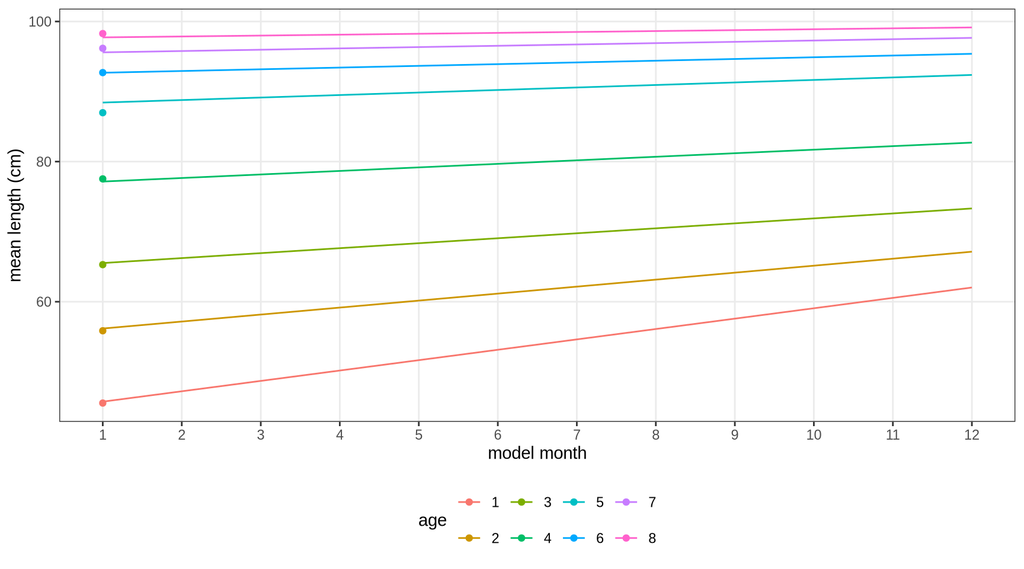

Figure 4: MFCL’s mean length-at-age by model month (month 1 is October), from its predicted length compositions by age (M3), with opal’s start-of-year length-at-age (points at month 1).

```r
lm_dt = data.table(month = rep(1:12, ncol(lfd$laa_month)), age = rep(seq_len(ncol(lfd$laa_month)), each = 12),
                   length = as.vector(lfd$laa_month))
ggplot(lm_dt[age <= 8], aes(month, length, colour = factor(age))) + geom_line() +
    geom_point(data = data.table(month = 1, age = 1:8, length = oc$growth$opal_length[1:8])) +
    scale_x_continuous(breaks = 1:12) +
    labs(x = "model month", y = "mean length (cm)", colour = "age")
```

The test changes only opal’s inputs: its growth fitted to MFCL’s mid-year lengths (the average of model months 6 and 7). Figure 5 compares profiles over B0 for the annual model with start-of-year and mid-year growth, the same with fisheries 1-7 split into one fishery per season (Section 8), and the quarterly-age model.

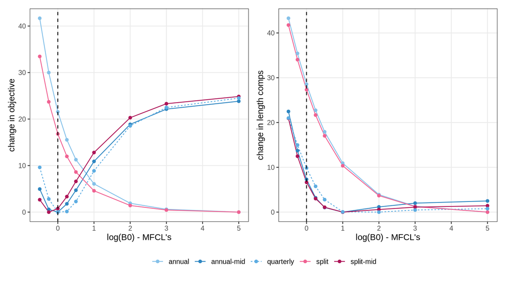

Figure 5: Profiles over log(B0) (relative to MFCL’s): change in the total objective (left) and in the length-composition component (right). annual: O1’s set-up; -mid: growth at MFCL’s mid-year lengths; split: one fishery per season for fisheries 1-7; quarterly: quarterly ages (B0 on the annual model’s scale).

```r
pp = P[is.finite(objective)]
g1 = ggplot(pp, aes(dlog_B0, d_objective, colour = variant, linetype = variant)) + geom_line() + geom_point() +
    geom_vline(xintercept = 0, linetype = 2) + scale_models() +
    labs(x = "log(B0) - MFCL's", y = "change in objective", colour = NULL, linetype = NULL)
g2 = ggplot(pp, aes(dlog_B0, d_lf, colour = variant, linetype = variant)) + geom_line() + geom_point() +
    geom_vline(xintercept = 0, linetype = 2) + scale_models() +
    labs(x = "log(B0) - MFCL's", y = "change in length comps", colour = NULL, linetype = NULL)
g1 + g2 + plot_layout(guides = "collect")
```

```r
knitr::kable(lfd$summary[, .(variant, `best log(B0) - MFCL's` = fmt(best_dlog_B0, 2),
                             `rise at +5` = fmt(rise_at_plus5, 1),
                             `depletion at MFCL's scale` = fmt(depletion_at_mfcl_scale, 3))], format = "pipe")
```

Table 7: Profile summaries: where the objective is smallest (log(B0) relative to MFCL’s), how much it rises at +5, and depletion at MFCL’s scale.

| variant | best log(B0) - MFCL’s | rise at +5 | depletion at MFCL’s scale |
| --- | --- | --- | --- |
| annual | 5.00 | 0.0 | 0.755 |
| annual-mid | 0.00 | 23.8 | 0.614 |
| split | 5.00 | 0.0 | 0.752 |
| split-mid | -0.25 | 24.9 | 0.608 |
| quarterly | 0.00 | 24.5 | 0.467 |

With mid-year growth the profile has a minimum near MFCL’s scale and the index fit improves, and O1-mid (O1 with mid-year growth, B0 estimated) converges at log(B0) 13.96 against MFCL’s 14.04. The length compositions on their own still favour a somewhat larger stock than MFCL’s.

The quarterly-age model, which gives each quarter MFCL’s length-at-age and selectivity and fits the length compositions by quarter, also has its minimum at MFCL’s scale and fits the indices far better than any annual variant (CPUE negative log-likelihood 0.71 at MFCL’s scale, against 15.73 for annual-mid and 44.66 for the O1 set-up). Its depletion at that B0 (0.467) is lower than the annual variants’, partly because its stock-recruitment curve is evaluated differently (Section 8); its B0 is not comparable with the annual models’ beyond being a scale.

## 7.1 Starting population

A B0 at MFCL’s does not give MFCL’s stock. MFCL scales its initial population with its own parameter (the total population scaling), separately from its stock-recruitment relationship, and its 1954 spawning biomass (6,594 kt) is about 5 times its Beverton-Holt B0, with 1954 recruitment 3.3 times its mean. O0 reproduces it only by imposing MFCL’s initial numbers (`init_rdev_a`); fitted opal models start from the unfished equilibrium at B0, as the assessment report describes but MFCL does not implement. O1-mid’s spawning biomass is 1,152 kt in 1954 and 425 kt in 2022, against MFCL’s 860 kt. Estimating the initial population, as MFCL does, closes most of the gap (O1i, Section 9).

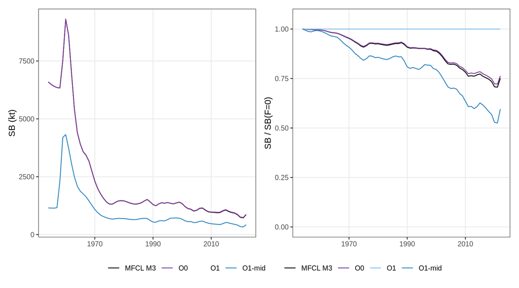

Figure 6: Spawning biomass and dynamic depletion: MFCL M3, O0, O1 and O1-mid. O1’s spawning biomass is off the scale.

```r
g1 = ggplot(TR[model != "O1"], aes(year, sb / 1e3, colour = model)) + geom_line() +
    scale_colour_manual(values = model_col, limits = c("MFCL M3", "O0", "O1", "O1-mid")) +
    labs(x = NULL, y = "SB (kt)", colour = NULL)
g2 = ggplot(TR, aes(year, dynamic_depletion, colour = model)) + geom_line() +
    scale_colour_manual(values = model_col, limits = c("MFCL M3", "O0", "O1", "O1-mid")) +
    coord_cartesian(ylim = c(0, 1.05)) + labs(x = NULL, y = "SB / SB(F=0)", colour = NULL)
g1 + g2 + plot_layout(guides = "collect")
```

# 8 Seasonal set-ups

Both set-ups use opal’s inputs only.

**Seasonal fisheries** (`mfcl_split_seasonal_fisheries()`). Fisheries 1-7, whose MFCL selectivity differs by season, become four fisheries each (36 fisheries), each with one season’s catch, selectivity and length compositions. This represents MFCL’s seasonal selectivity exactly in the annual-age model and lets opal estimate seasonal curves; on its own it does not change the length-composition pull (Figure 5). Fits with opal’s selectivity on the split fisheries are in Section 9 (O2-split).

**Quarterly ages** (`mfcl_quarterly_ages()`). opal’s time step and age classes become quarters: 48 quarterly ages and 276 steps, one season each. Recruitment stays annual: the recruitment deviations of the three quarters without recruitment are fixed at -30, and the initial numbers of quarterly ages that do not exist (cohorts recruit once a year) are near zero. Then:

- quarterly age $q = 4(a - 1) + s$ holds annual age class $a$ in season $s$ only, so a selectivity by quarterly age is MFCL’s seasonal selectivity (exactly, except for the plus group, which is present in every season);
- length-at-age, and weight at the time of catch, are MFCL’s at each quarter’s fishing month (opal’s growth fitted to them, RMSE 0.68 cm);
- the length compositions are fitted by quarter, and the indices in the quarter they sample;
- M is MFCL’s per quarter.

```r
knitr::kable(lfd$o0q_check[, .(quantity, `rel. diff.` = sci(rel_diff, 1))], format = "pipe")
```

Table 8: Quarterly-age model at MFCL’s values against MFCL M3.

| quantity | rel. diff. |
| --- | --- |
| numbers at age, first year | 1.7e-06 |
| recruitment | 4.0e-05 |
| spawning biomass (max) | 2.4e-02 |
| spawning biomass (2022) | 1.8e-02 |

The cost is the stock-recruitment relationship: opal treats every step as a recruitment, so with one recruitment in four steps its B0 is about four times the unfished spawning biomass and the curve is evaluated at a quarter of the usual relative stock size, which changes what steepness means. Depletion has to be taken against opal’s unfished projection, and B0 treated as a scale parameter.

# 9 Fits with the quarterly ages and opal’s own selectivity

Five further fits (`scripts/05-fit-opal-selectivity.r`), with growth, steepness, sigma<sub>R</sub>, M and the biology held as in O1. All estimate the initial population (Section 7.1): one deviation for the 1954 recruits (age 1) and one shared by the older ages, which sets the level of the initial age structure (in the quarterly models the plus group is tied to the older ages, see below), without the penalty against the stock-recruitment relationship (opal’s `lambdas$init_rec = 0`), as in MFCL.

- **O1i**: O1-mid (annual, mid-year growth, MFCL’s selectivity) with the initial population estimated.
- **O1q**: the quarterly-age model with MFCL’s seasonal selectivity fixed; B0, the first-quarter recruitment deviations (1955-2020), the initial population and the catchabilities estimated.
- **O2**: the annual model with mid-year growth (O1-mid) and opal’s own length-based selectivity: double normals (a logistic for the longline index, which MFCL holds non-decreasing), shared within MFCL’s selectivity groups (fisheries 1 and 3, 2 and 4, 5 and 6). Three of the double normal’s six parameters are estimated: the peak and the two widths, within bounds (peak within 2 SD of the length bins, widths in [-6, 3]). The plateau and final selectivity are held at the starting curves’, which are fitted to MFCL’s selectivity-at-age through opal’s length-at-age, and the initial selectivity near zero. (A first attempt with five of the six free ran most widths, plateaus and final selectivities to their bounds.)
- **O2-split**: O2 with fisheries 1-7 split into one fishery per season, sharing parameters within MFCL’s groups and seasons.
- **O2q**: O1q with opal’s own selectivity (one curve per group, whose selectivity-at-age varies by quarter through growth).

```r
SS = sel$summary
knitr::kable(SS[, .(model, `n par` = n_par, `max grad.` = sci(max_gradient), `at bound` = at_bound,
                    CPUE = fmt(cpue, 1), `length comps` = fmt(lf, 1),
                    `SB 2022` = fmt(sb_end / 1e3, 0), depletion = fmt(depletion_end, 3))], format = "pipe")
```

Table 9: Fits with quarterly ages or opal’s selectivity. Objectives of the quarterly models include a constant from the recruitment deviations fixed at -30 and are not comparable with the annual models’. At bound: estimated parameters at a bound. SB in thousand tonnes; depletion against opal’s unfished projection.

| model | n par | max grad. | at bound | CPUE | length comps | SB 2022 | depletion |
| --- | --- | --- | --- | --- | --- | --- | --- |
| O1i | 71 | 1.1e-04 | 0 | -3.6 | 5,812.3 | 709 | 0.720 |
| O1q | 71 | 1.0e-03 | 0 | -6.5 | 8,567.0 | 695 | 0.671 |
| O2 | 106 | 1.4e+00 | 16 | 0.3 | 5,737.1 | 210 | 0.431 |
| O2-split | 142 | 7.8e+06 | 20 | 352.3 | 8,747.0 | 1,173 | 0.818 |
| O2q | 106 | 6.0e+00 | 18 | 2.0 | 8,597.3 | 207 | 0.365 |

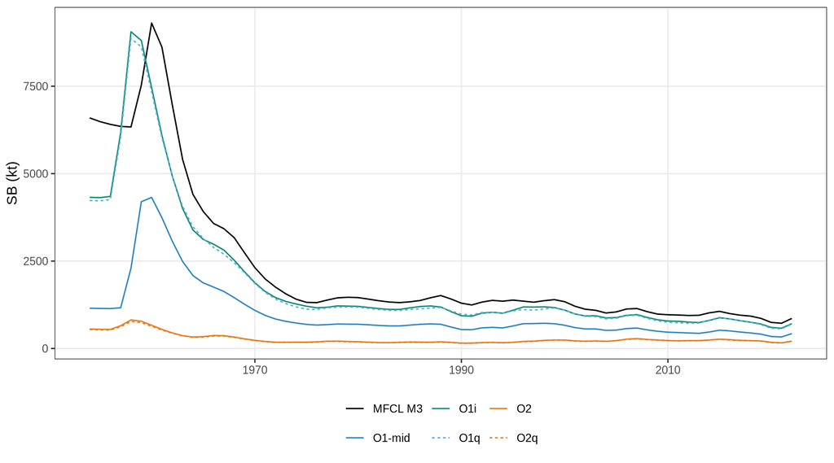

Figure 7: Spawning biomass: MFCL M3 and the opal fits with MFCL’s selectivity (O1-mid with the initial population at equilibrium; O1i and O1q with it estimated) or opal’s own (O2, O2q).

```r
tr2 = rbind(TR[model %in% c("MFCL M3", "O1-mid"), .(model, year, sb)],
            sel$trajectory[model %in% c("O1i", "O1q", "O2", "O2q"), .(model, year, sb)])
ggplot(tr2, aes(year, sb / 1e3, colour = model, linetype = model)) + geom_line() + scale_models() +
    labs(x = NULL, y = "SB (kt)", colour = NULL, linetype = NULL)
```

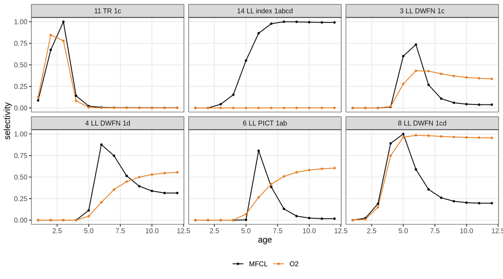

Figure 8: Selectivity-at-age: MFCL’s (averaged over seasons) and O2’s estimates, for selected fisheries.

```r
ff = c(3, 4, 6, 8, 11, 14)
sel_dt = rbind(
  data.table(source = "MFCL", fishery = rep(ff, each = 12), age = rep(1:12, length(ff)),
             sel = as.vector(t(oc$selectivity$average[ff, ]))),
  data.table(source = "O2", fishery = rep(ff, each = 12), age = rep(1:12, length(ff)),
             sel = as.vector(t(sel$fits$O2$sel_fya[ff, ]))))
sel_dt[, name := oc$fishery_names[fishery]]
ggplot(sel_dt, aes(age, sel, colour = source)) + geom_line() + geom_point(size = 0.8) +
    scale_colour_manual(values = model_col) + facet_wrap(~name) + labs(x = "age", y = "selectivity", colour = NULL)
```

With MFCL’s selectivity, estimating the initial population brings opal close to MFCL. O1i converges (largest gradient 1.1e-04) with 709 kt in 2022 and depletion 0.72, against MFCL’s 860 kt and 0.75. O1q (quarterly ages) agrees with it: the age-1 and older-age initial deviations are close to O1i’s and it ends at 695 kt. In the quarterly models the plus group shares the older ages’ initial level, with its equilibrium offset supplied through `init_bias_adj_a` (a fixed input; opal’s map cannot tie parameters with an offset); estimated on its own, it took the whole initial stock while the classes between went empty.

With opal’s selectivity the fits do not settle on sensible curves, even with three of the six parameters free. In O2 and O2q many double-normal widths go to their bounds (knife-edge limbs), the largest gradients stay above 1, and the stock is a quarter of MFCL’s in 2022. O2-split ends at a point where the gradient explodes as its curves collapse.

## 9.1 Why the double normals collapse

```r
sdv = function(p, L) { m = sum(p * L) / sum(p); sqrt(sum(p * (L - m)^2) / sum(p)) }
spread = sdg$pooled[, .(obs_sd = sdv(observed, length), O1i_sd = sdv(O1i, length), O2_sd = sdv(O2, length)), by = fishery]
bf = merge(sdg$by_fishery, spread, by = "fishery")[order(-gain)]
knitr::kable(bf[, .(name, `n obs` = n_obs, `O1i NLL` = fmt(O1i_nll, 1), `O2 NLL` = fmt(O2_nll, 1),
                    `observed SD` = fmt(obs_sd, 1), `O1i SD` = fmt(O1i_sd, 1), `O2 SD` = fmt(O2_sd, 1))],
             format = "pipe")
```

Table 10: O2 (opal’s selectivity) against O1i (MFCL’s), by fishery: length-composition negative log-likelihood, and the standard deviation of the observed and predicted compositions pooled over years (cm).

| name | n obs | O1i NLL | O2 NLL | observed SD | O1i SD | O2 SD |
| --- | --- | --- | --- | --- | --- | --- |
| 11 TR 1c | 25 | 1,516.6 | 1,454.8 | 7.1 | 7.3 | 6.8 |
| 3 LL DWFN 1c | 54 | 1,309.2 | 1,265.3 | 7.4 | 7.6 | 8.6 |
| 12 TR 1d | 7 | 285.5 | 262.5 | 9.3 | 9.7 | 9.7 |
| 15 TR index 1ef | 25 | 401.5 | 398.3 | 6.7 | 7.3 | 6.8 |
| 14 LL index 1abcd | 57 | 161.3 | 158.1 | 6.9 | 10.2 | 8.3 |
| 9 LL PICT 1cd | 14 | 68.8 | 68.1 | 9.0 | 9.4 | 8.8 |
| 10 LL AU/NZ 1cd | 27 | 390.2 | 389.5 | 11.1 | 11.2 | 11.0 |
| 8 LL DWFN 1cd | 42 | 303.2 | 302.7 | 10.9 | 11.2 | 11.1 |
| 13 DN 1cd | 2 | 10.3 | 10.2 | 6.8 | 8.2 | 9.9 |
| 7 LL AU/NZ 1ab | 13 | 211.2 | 217.4 | 7.4 | 8.3 | 9.6 |
| 4 LL DWFN 1d | 49 | 504.5 | 512.0 | 6.5 | 7.9 | 9.1 |
| 6 LL PICT 1ab | 31 | 650.0 | 698.3 | 5.8 | 7.3 | 8.9 |

O2 gains most on the troll fisheries 11 and 12 and the longline fishery 3, and loses on fishery 6. The northern longline fisheries’ (3, 4, 6, 7) and the longline index’s compositions are narrower (SD 5.8-7.4 cm) than the model predicts even with MFCL’s selectivity, and about as narrow as the spread of length within a single age at the ages they catch (MFCL’s SD of length is 5.9-7.6 cm at ages 5-12). Under the multinomial likelihood every tail bin counts, so opal narrows its predicted catch with a window-shaped selectivity in length: the knife-edge widths, which flatten selectivity-at-age over the older ages (Figure 8). MFCL’s robust normal likelihood is much less sensitive to the tails.

```r
LT = lft$summary
knitr::kable(LT[, .(model, `max grad.` = sci(max_gradient), `widths at bound` = widths_at_bound,
                    CPUE = fmt(cpue, 1), `length comps` = fmt(lf, 1), `SD oldest age` = fmt(sd2, 2),
                    `SB 1954` = fmt(sb_1954 / 1e3, 0), `SB 2022` = fmt(sb_2022 / 1e3, 0),
                    depletion = fmt(depletion_2022, 3))], format = "pipe")
```

Table 11: Tests on O2 (and O1i) of the length-composition treatment (`scripts/07-test-lf-likelihood.r`): pool: tail bins below 0.5% and above 99.5% of each fishery’s observed composition pooled; DM: Dirichlet-multinomial with each fishery’s dispersion estimated; SD2: the SD of length at the oldest age estimated; all: the three together. Widths at bound: double-normal widths at a bound (of 22). Length-composition likelihoods differ in form between variants. SB in thousand tonnes.

| model | max grad. | widths at bound | CPUE | length comps | SD oldest age | SB 1954 | SB 2022 | depletion |
| --- | --- | --- | --- | --- | --- | --- | --- | --- |
| O1i | 1.1e-04 | NA | -3.6 | 5,812.3 | 7.62 | 4,322 | 709 | 0.720 |
| O2 | 1.4e+00 | 15 | 0.3 | 5,737.1 | 7.62 | 557 | 210 | 0.431 |
| O2-pool | 1.4e+00 | 14 | 0.7 | 5,544.0 | 7.62 | 533 | 208 | 0.429 |
| O2-DM | 4.7e-01 | 19 | -4.2 | 5,397.3 | 7.62 | 292 | 194 | 0.411 |
| O2-SD2 | 5.0e-01 | 10 | -7.0 | 5,486.7 | 4.92 | 8,217 | 1,203 | 0.816 |
| O2-all | 1.1e+00 | 13 | -16.1 | 4,962.4 | 4.17 | 6,999 | 986 | 0.782 |
| O1i-all | 2.5e-01 | NA | -15.2 | 5,129.4 | 5.58 | 11,746 | 1,874 | 0.873 |

Pooling the tails changes little. The Dirichlet-multinomial’s dispersion goes to its upper bound (the multinomial) for most fisheries, since the sample sizes already carry MFCL’s Francis weights, except the longline index and the troll fisheries; the knife-edges remain. Estimating the SD of length at the oldest age matters: the compositions want 4.2-4.9 cm instead of MFCL’s 7.6, fewer widths reach their bounds, the index fit improves, and the scale changes from a quarter of MFCL’s to more than it. With all three (O2-all) the fit to both data types is the best and the stock is closest to MFCL’s (986 kt and 0.78 in 2022). The scale is therefore sensitive to the assumed spread of length at age, which MFCL fixes from its growth estimates with the age-at-length data. None of these fits is fully converged (largest gradients 0.25-1.4) and 10-19 widths still sit at bounds, so length-based double normals need further constraint (a width fixed, or priors) with the SD of length estimated. Age-based curves (1) are the alternative pursued here.

## 9.2 Age-based and hybrid selectivity

`scripts/08-fit-age-selectivity.r` evaluates the double normals on age (opal’s `sel_basis_f = 2`) instead of on length through the length-at-age key, with the same three parameters free and the same groups; starting curves are fitted directly to MFCL’s selectivity-at-age. Growth then affects only the predicted length compositions.

- **O3**: age-based curves for every fishery (the longline index logistic).
- **O3-SD2**, **O3-all**: as O2-SD2 and O2-all.
- **O4**: hybrid, with age-based curves for the longline fisheries and the index and length-based ones for the troll and driftnet fisheries (11, 12, 13, 15).
- **O4-all**: O4 with tail pooling, the Dirichlet-multinomial and the SD of length at the oldest age estimated.

```r
AS = asel$summary
knitr::kable(AS[, .(model, `max grad.` = sci(max_gradient), `widths at bound` = widths_at_bound,
                    CPUE = fmt(cpue, 1), `length comps` = fmt(lf, 1), `SD oldest age` = fmt(sd2, 2),
                    `SB 1954` = fmt(sb_1954 / 1e3, 0), `SB 2022` = fmt(sb_2022 / 1e3, 0),
                    depletion = fmt(depletion_2022, 3))], format = "pipe")
```

Table 12: Fits with age-based or hybrid selectivity, against O1i (MFCL’s selectivity), O2 and O2-all (length-based). Widths at bound: double-normal widths at a bound (of 22). Length-composition likelihoods of the -all variants (pooled, Dirichlet-multinomial) differ in form from the others. SB in thousand tonnes.

| model | max grad. | widths at bound | CPUE | length comps | SD oldest age | SB 1954 | SB 2022 | depletion |
| --- | --- | --- | --- | --- | --- | --- | --- | --- |
| O1i | 1.1e-04 | NA | -3.6 | 5,812.3 | 7.62 | 4,322 | 709 | 0.720 |
| O2 | 1.4e+00 | 15 | 0.3 | 5,737.1 | 7.62 | 557 | 210 | 0.431 |
| O2-all | 1.1e+00 | 13 | -16.1 | 4,962.4 | 4.17 | 6,999 | 986 | 0.782 |
| O3 | 5.0e+00 | 8 | -14.4 | 6,870.5 | 7.62 | 3,088 | 498 | 0.643 |
| O3-SD2 | 4.3e+00 | 10 | -16.7 | 6,793.2 | 9.33 | 1,952 | 342 | 0.551 |
| O3-all | 5.4e-01 | 5 | -21.5 | 5,053.5 | 5.50 | 3,966 | 622 | 0.692 |
| O4 | 1.0e+00 | 7 | -7.1 | 5,598.9 | 7.62 | 5,669 | 886 | 0.764 |
| O4-all | 4.0e-01 | 5 | -18.4 | 4,939.3 | 4.92 | 3,771 | 591 | 0.680 |

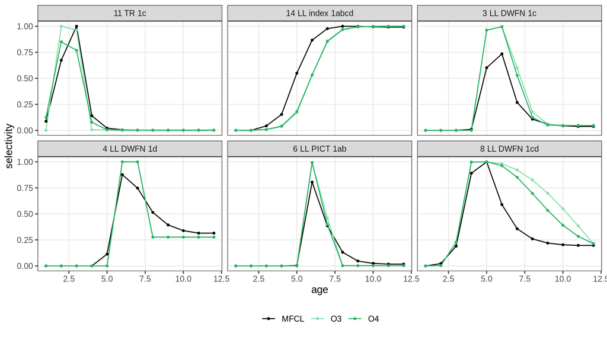

Figure 9: Selectivity-at-age: MFCL’s (averaged over seasons), O3’s (age-based) and O4’s (hybrid) for selected fisheries.

```r
sa = asel$sel_age[model %in% c("MFCL", "O3", "O4") & fishery %in% c(3, 4, 6, 8, 11, 14)]
ggplot(sa, aes(age, sel, colour = model)) + geom_line() + geom_point(size = 0.8) +
    scale_colour_manual(values = model_col) + facet_wrap(~name) + labs(x = "age", y = "selectivity", colour = NULL)
```

Age-based curves keep MFCL’s domed shapes, with far fewer widths at their bounds, and fit every longline fishery’s compositions better than MFCL’s own selectivity does (O1i). They fail for the troll fisheries: these catch young fish (ages 1-4) whose lengths change quickly through the year, and a curve on whole ages cannot follow which lengths are caught in each season, so O3 loses about 1000 units on fishery 11 alone. The hybrid O4 keeps the age-based curves for the longline fisheries and length-based ones for troll and driftnet. It fits the compositions better than any other multinomial fit (O1i included), and its stock is the closest to MFCL’s: 886 kt and depletion 0.76 in 2022, against 860 kt and 0.75. It is not fully converged (largest gradient 1.0) and 7 widths are at bounds (converged as O4-fix below); with the SD of length estimated as well (O4-all) the gradient is smaller but the stock lower (591 kt).

### 9.2.1 Converging the hybrid, and its quarterly version

`scripts/09-fit-hybrid-selectivity.r` fixes each selectivity parameter that O4 left at a bound at that bound and refits the rest (O4-fix), and fits the hybrid on the quarterly-age model (O4q: age-based curves over the 48 quarterly ages for the longline fisheries and index, length-based for troll and driftnet, the initial population estimated with the plus group tied, started from O1q), then fixes its bounded parameters too (O4q-fix).

```r
HY = hyb$summary
knitr::kable(HY[, .(model, `n par` = n_par, `max grad.` = sci(max_gradient), fixed = sel_fixed,
                    CPUE = fmt(cpue, 1), `length comps` = fmt(lf, 1),
                    `SB 1954` = fmt(sb_1954 / 1e3, 0), `SB 2022` = fmt(sb_2022 / 1e3, 0),
                    depletion = fmt(depletion_2022, 3))], format = "pipe")
```

Table 13: The hybrid selectivity model converged (O4-fix) and on quarterly ages (O4q, O4q-fix), with O1i and O1q (MFCL’s selectivity) and O4. Fixed: selectivity parameters fixed at the bound O4 or O4q left them at. Quarterly models’ objectives and length-composition likelihoods (by quarter) are not comparable with the annual models’. SB in thousand tonnes.

| model | n par | max grad. | fixed | CPUE | length comps | SB 1954 | SB 2022 | depletion |
| --- | --- | --- | --- | --- | --- | --- | --- | --- |
| O1i | 71 | 1.1e-04 | NA | -3.6 | 5,812.3 | 4,322 | 709 | 0.720 |
| O1q | 71 | 1.0e-03 | NA | -6.5 | 8,567.0 | 4,231 | 695 | 0.671 |
| O4 | 106 | 1.0e+00 | NA | -7.1 | 5,598.9 | 5,669 | 886 | 0.764 |
| O4-fix | 99 | 7.7e-04 | 7 | -7.1 | 5,598.9 | 5,669 | 886 | 0.764 |
| O4q | 106 | 6.3e+00 | NA | -11.1 | 8,423.7 | 1,994 | 359 | 0.505 |
| O4q-fix | 97 | 1.9e-03 | 9 | -11.1 | 8,423.7 | 1,994 | 359 | 0.505 |

Fixing the bounded parameters leaves the objectives unchanged and the fits converge: O4’s and O4q’s large gradients were only those of parameters pressing on their bounds. O4-fix (largest gradient 7.7e-04) keeps O4’s result, the closest to MFCL of the fits here. The quarterly hybrid O4q-fix also converges and fits both the indices and the quarterly compositions better than O1q, but its stock is about half O1q’s (359 kt and depletion 0.50 in 2022).

### 9.2.2 Open issue: the quarterly hybrid’s lower stock

Why O4q-fix’s stock is about half of O1q’s and O4-fix’s is not established. One hypothesis is seasonal selectivity: on quarterly ages each age-based curve is smooth in quarterly age, so it cannot follow MFCL’s selectivity, which differs by season for fisheries 1-7 and which O1q holds exactly, and the scale moves with the curves. This has not been tested, and other differences between O4q-fix and O1q could account for it: the troll and driftnet curves are re-estimated on length, the plus group’s selectivity follows the curve rather than MFCL’s, and the shared groups’ curves are estimated rather than fixed.

Splitting fisheries by season has been tried only with length-based curves (O2-split, which did not converge) and, with MFCL’s selectivity fixed, in the B0 profiles (Figure 5); it has not been tried with age-based or hybrid curves. The test that would isolate the cause is O4q with the longline selectivity fixed at MFCL’s quarterly values and only the troll and driftnet curves estimated: if its stock returns to O1q’s, the longline curves’ seasonality is the cause; if not, the troll and driftnet curves or the plus group are. A seasonal split of the hybrid on annual ages would test the same from the other side.

# 10 From MFCL to the best opal model

Table 14 and Figure 10 trace the steps from MFCL M3 to O4-fix, the best converged opal model here. Each step changes one thing from the step it follows, through opal’s inputs only. The quarterly-age branch (O1q, O4q-fix) is listed for comparison.

```r
PG = data.table(
  model = c("MFCL M3", "O0", "O1", "O1-mid", "O1i", "O2", "O2-all", "O4", "O4-fix", "O1q", "O4q-fix"),
  from  = c("", "MFCL M3", "O0", "O1", "O1-mid", "O1i", "O2", "O2", "O4", "O1i", "O1q"),
  change = c("target: region 1, no movement, growth fixed without age-at-length",
             "opal at MFCL's values: season-averaged selectivity, growth (age-specific K), M, recruitment and initial numbers imposed",
             "B0, recruitment deviations and catchabilities estimated; unfished initial population",
             "growth refitted to MFCL's mid-year lengths",
             "initial population estimated (two deviations, no stock-recruitment penalty)",
             "opal's length-based double normals (peak and two widths estimated)",
             "SD of length at the oldest age estimated, tail pooling, Dirichlet-multinomial",
             "age-based double normals for longline, length-based for troll and driftnet",
             "selectivity parameters at bounds fixed there",
             "quarterly ages and steps (recruitment annual), MFCL's seasonal selectivity",
             "hybrid selectivity on quarterly ages, parameters at bounds fixed"),
  fit = c("", "not fitted", "log(B0) at its bound", "converged", "converged",
          "not converged; 16 at bounds", "not converged; 22 at bounds", "not converged; 7 at bounds",
          "converged", "converged", "converged"))
PG = merge(PG, ALL[year == min(year), .(model, sb_1954 = sb)], by = "model", sort = FALSE)
PG = merge(PG, ALL[year == max(year), .(model, sb_2022 = sb, dep_2022 = depletion)], by = "model", sort = FALSE)
sb_kt = function(x) ifelse(x > 1e8, sci(x / 1e3), fmt(x / 1e3, 0))
pipe_table(PG[, .(model, from, change, fit, `SB 1954` = sb_kt(sb_1954),
                  `SB 2022` = sb_kt(sb_2022), `dep. 2022` = fmt(dep_2022, 2))],
           c(9, 9, 40, 16, 9, 9, 8))
```

Table 14: Steps from MFCL M3 to O4-fix (and the quarterly-age branch). Each row’s change is relative to the step named in ‘from’. SB in thousand tonnes; depletion in 2022 against the unfished projection.

| model | from | change | fit | SB 1954 | SB 2022 | dep. 2022 |
| --- | --- | --- | --- | --- | --- | --- |
| MFCL M3 |  | target: region 1, no movement, growth fixed without age-at-length |  | 6,594 | 860 | 0.75 |
| O0 | MFCL M3 | opal at MFCL’s values: season-averaged selectivity, growth (age-specific K), M, recruitment and initial numbers imposed | not fitted | 6,594 | 873 | 0.76 |
| O1 | O0 | B0, recruitment deviations and catchabilities estimated; unfished initial population | log(B0) at its bound | 3.6e+06 | 2.5e+06 | 1.00 |
| O1-mid | O1 | growth refitted to MFCL’s mid-year lengths | converged | 1,152 | 425 | 0.60 |
| O1i | O1-mid | initial population estimated (two deviations, no stock-recruitment penalty) | converged | 4,322 | 709 | 0.72 |
| O2 | O1i | opal’s length-based double normals (peak and two widths estimated) | not converged; 16 at bounds | 557 | 210 | 0.43 |
| O2-all | O2 | SD of length at the oldest age estimated, tail pooling, Dirichlet-multinomial | not converged; 22 at bounds | 6,999 | 986 | 0.78 |
| O4 | O2 | age-based double normals for longline, length-based for troll and driftnet | not converged; 7 at bounds | 5,669 | 886 | 0.76 |
| O4-fix | O4 | selectivity parameters at bounds fixed there | converged | 5,669 | 886 | 0.76 |
| O1q | O1i | quarterly ages and steps (recruitment annual), MFCL’s seasonal selectivity | converged | 4,231 | 695 | 0.67 |
| O4q-fix | O1q | hybrid selectivity on quarterly ages, parameters at bounds fixed | converged | 1,994 | 359 | 0.50 |

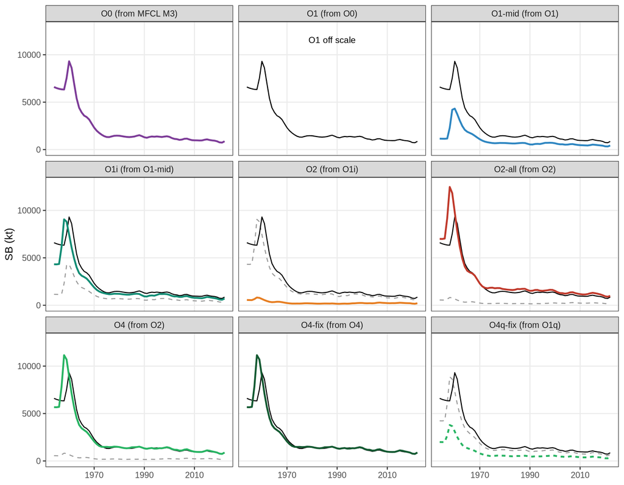

Figure 10: Spawning biomass at each step (coloured) against MFCL M3 (black) and the step it changes (grey dashed). O1’s spawning biomass is off the scale. The last panel is the quarterly-age branch.

```r
steps = PG[model != "MFCL M3" & model != "O1q"]
lab = setNames(paste0(steps$model, " (from ", steps$from, ")"), steps$model)
pg_dt = rbindlist(lapply(steps$model, function(m) rbind(
    ALL[model == m, .(panel = lab[m], model, role = "step", year, sb)],
    ALL[model == steps[model == m, from], .(panel = lab[m], model, role = "from", year, sb)],
    ALL[model == "MFCL M3", .(panel = lab[m], model, role = "MFCL", year, sb)])))
pg_dt[, panel := factor(panel, levels = lab)]
y_top = 1.03 * max(pg_dt[model != "O1", sb]) / 1e3
ggplot(mapping = aes(year, sb / 1e3)) +
    geom_line(data = pg_dt[role == "from"], colour = "grey60", linetype = 2) +
    geom_line(data = pg_dt[role == "MFCL"], colour = "black") +
    geom_line(data = pg_dt[role == "step"], aes(colour = model, linetype = model), linewidth = 0.9) +
    geom_text(data = data.table(panel = factor(lab[["O1"]], levels = lab), year = 1988, sb = 0.9e3 * y_top),
              aes(label = "O1 off scale"), size = 3.2) +
    scale_models() + coord_cartesian(ylim = c(0, y_top)) + facet_wrap(~panel, ncol = 3) +
    labs(x = NULL, y = "SB (kt)", colour = NULL, linetype = NULL) + guides(colour = "none", linetype = "none")
```

- **O0** shows that opal’s population dynamics reproduce MFCL’s when given its values; the 2.1% gap is catch timing (Section 5).
- **O1 to O1-mid** removes the length-composition pull towards an unfished stock by giving opal MFCL’s mid-year lengths at age (Section 7).
- **O1-mid to O1i** frees the initial population from the stock-recruitment relationship, as MFCL does (Section 7.1); with MFCL’s selectivity this is enough to come close to MFCL.
- **O1i to O2** replaces MFCL’s selectivity with opal’s length-based double normals, which collapse (Section 9.1). Estimating the SD of length (O2-all) restores the scale but does not converge.
- **O2 to O4 to O4-fix** evaluates the longline curves on age, which keeps their domed shapes, and fixes the parameters left at bounds. O4-fix is the only fit with opal’s own selectivity that converges and is close to MFCL: 5,669 against 6,594 kt in 1954 and 886 against 860 kt in 2022 (depletion 0.76 against 0.75), with a higher peak in the early 1960s (11,151 against 9,306 kt).
- **The quarterly branch** reproduces O1i with MFCL’s seasonal selectivity (O1q) but not O4-fix with the hybrid curves (O4q-fix; open issue in the hybrid section).

# 11 Remaining differences and what opal would need

Table 15 lists the features of the MFCL model that opal does not have, the workaround used here to minimise the difference, and what remains different in O4-fix.

```r
gaps = data.table(
  MFCL = c("Two regions with movement; recruitment distributed over regions",
           "Conditional age-at-length likelihood",
           "VB growth with independent mean lengths at ages 2-4; SD log-linear in length",
           "Length compositions predicted at each sample's date, with within-year growth",
           "Seasonal selectivity (fisheries 1-7)",
           "Catch-conditioned Baranov at each fishing incident's date (several per quarter for troll)",
           "Length-based cubic-spline selectivity, grouped across fisheries",
           "Length compositions per incident, robust normal likelihood",
           "Index abundance at the incident's date",
           "Recruitment from the previous year's spawning potential; last two at the mean",
           "Initial population scaled by its own parameter, apart from the stock-recruitment relationship"),
  opal = c("one region",
           "none",
           "VB, Richards, cessation, age-specific K; SD or CV linear in length",
           "start-of-year length-at-age; annual compositions",
           "selectivity by year",
           "Pope removal at the start of each season",
           "logistic, double normal, double Richards, on length or age; no mirrors (sharing via map)",
           "annual compositions; multinomial, Dirichlet, Dirichlet-multinomial",
           "start of the season",
           "same year's spawning biomass; free deviations",
           "unfished (or init_F) equilibrium at B0, with optional initial deviations"),
  workaround = c("MFCL bridge to region 1 (M1, M1b, M2)",
                 "dropped, growth fixed at MFCL's estimates (M3)",
                 "age-specific K fitted to MFCL's lengths at age (O0; 0.5 cm RMSE); SD from MFCL",
                 "growth fitted to MFCL's mid-year lengths (O1-mid on); or quarterly ages (O1q)",
                 "catch-weighted average (O0-O1i); estimated non-seasonal curves (O4-fix); or seasonal fisheries / quarterly ages",
                 "none",
                 "double normals with 3 of 6 parameters free, shared within MFCL's groups; age-based for longline, length-based for troll and driftnet (O4); parameters at bounds fixed (O4-fix)",
                 "summed by fishery and year; Francis divisors kept; multinomial",
                 "none",
                 "MFCL's recruitment imposed (O0); last two deviations at the curve (O1 on)",
                 "two initial deviations (age 1, older ages) without the stock-recruitment penalty (O1i on)"),
  remaining = c("compared with the bridge model, not the assessment: region 1's 1954 SB is 7.6 times M0's",
                "none beyond the bridge",
                "MFCL's SD of length (7.6 cm at the oldest age); the longline compositions want 4-5 cm",
                "one length-at-age per year; troll fisheries (young, fast-growing fish) need length-based curves",
                "<0.1% on SB at MFCL's values; effect on estimated selectivity untested (O4q-fix's lower stock unexplained)",
                "up to ~2% on SB (O0 against the replays)",
                "7 parameters fixed at bounds; curves estimated, not MFCL's",
                "tail bins weigh more than under MFCL's likelihood; drives the knife-edges in O2",
                "small (not measured)",
                "recruitment estimated by opal; timing of the stock-recruitment link differs",
                "initial age structure has two levels, not MFCL's shape; 1954 SB 14% below MFCL's"))
setnames(gaps, c("MFCL", "opal", "workaround here", "remaining in O4-fix"))
pipe_table(gaps, c(25, 20, 30, 25))
```

Table 15: Features of the MFCL model that opal does not have: opal’s nearest equivalent, the workaround used here (and the step it enters), and what remains different in O4-fix.

| MFCL | opal | workaround here | remaining in O4-fix |
| --- | --- | --- | --- |
| Two regions with movement; recruitment distributed over regions | one region | MFCL bridge to region 1 (M1, M1b, M2) | compared with the bridge model, not the assessment: region 1’s 1954 SB is 7.6 times M0’s |
| Conditional age-at-length likelihood | none | dropped, growth fixed at MFCL’s estimates (M3) | none beyond the bridge |
| VB growth with independent mean lengths at ages 2-4; SD log-linear in length | VB, Richards, cessation, age-specific K; SD or CV linear in length | age-specific K fitted to MFCL’s lengths at age (O0; 0.5 cm RMSE); SD from MFCL | MFCL’s SD of length (7.6 cm at the oldest age); the longline compositions want 4-5 cm |
| Length compositions predicted at each sample’s date, with within-year growth | start-of-year length-at-age; annual compositions | growth fitted to MFCL’s mid-year lengths (O1-mid on); or quarterly ages (O1q) | one length-at-age per year; troll fisheries (young, fast-growing fish) need length-based curves |
| Seasonal selectivity (fisheries 1-7) | selectivity by year | catch-weighted average (O0-O1i); estimated non-seasonal curves (O4-fix); or seasonal fisheries / quarterly ages | <0.1% on SB at MFCL’s values; effect on estimated selectivity untested (O4q-fix’s lower stock unexplained) |
| Catch-conditioned Baranov at each fishing incident’s date (several per quarter for troll) | Pope removal at the start of each season | none | up to ~2% on SB (O0 against the replays) |
| Length-based cubic-spline selectivity, grouped across fisheries | logistic, double normal, double Richards, on length or age; no mirrors (sharing via map) | double normals with 3 of 6 parameters free, shared within MFCL’s groups; age-based for longline, length-based for troll and driftnet (O4); parameters at bounds fixed (O4-fix) | 7 parameters fixed at bounds; curves estimated, not MFCL’s |
| Length compositions per incident, robust normal likelihood | annual compositions; multinomial, Dirichlet, Dirichlet-multinomial | summed by fishery and year; Francis divisors kept; multinomial | tail bins weigh more than under MFCL’s likelihood; drives the knife-edges in O2 |
| Index abundance at the incident’s date | start of the season | none | small (not measured) |
| Recruitment from the previous year’s spawning potential; last two at the mean | same year’s spawning biomass; free deviations | MFCL’s recruitment imposed (O0); last two deviations at the curve (O1 on) | recruitment estimated by opal; timing of the stock-recruitment link differs |
| Initial population scaled by its own parameter, apart from the stock-recruitment relationship | unfished (or init_F) equilibrium at B0, with optional initial deviations | two initial deviations (age 1, older ages) without the stock-recruitment penalty (O1i on) | initial age structure has two levels, not MFCL’s shape; 1954 SB 14% below MFCL’s |

In order of their effect on this stock: length-at-age at the time of sampling (or a sub-annual time step with annual recruitment, which would also give seasonal selectivity, catch weight and index timing), then catch timing within the season, then multiple regions, then a conditional age-at-length likelihood for estimating growth.

# 12 Reproducing this document

From any working directory (`CLAUDE.md` has the R environment):

```bash
Rscript --no-init-file case-studies/swpo-alb/scripts/01-build-mfcl-bridge.r
Rscript --no-init-file case-studies/swpo-alb/scripts/02-compare-mfcl-bridge.r
Rscript --no-init-file case-studies/swpo-alb/scripts/03-convert-fit-swpo-alb-opal.r
Rscript --no-init-file case-studies/swpo-alb/scripts/04-length-comp-diagnostics.r
Rscript --no-init-file case-studies/swpo-alb/scripts/05-fit-opal-selectivity.r
Rscript --no-init-file case-studies/swpo-alb/scripts/06-diagnose-selectivity.r
Rscript --no-init-file case-studies/swpo-alb/scripts/07-test-lf-likelihood.r
Rscript --no-init-file case-studies/swpo-alb/scripts/08-fit-age-selectivity.r
Rscript --no-init-file case-studies/swpo-alb/scripts/09-fit-hybrid-selectivity.r
quarto render case-studies/swpo-alb/vignettes/swpo-alb-mfcl-to-opal.qmd
```

Scripts 05-09 build on 05’s fits (08 also on 07’s, 09 on 08’s), so run them in order. The MFCL fits, opal fits and profiles are cached (`SWPO_ALB_REFIT=true` repeats them). The document reads only `vignettes/data/`.

## References

Anderson, Sean C., Eric J. Ward, Philina A. English, Lewis A. K. Barnett, and James T. Thorson. 2022. “sdmTMB: An R Package for Fast, Flexible, and User-Friendly Generalized Linear Mixed Effects Models with Spatial and Spatiotemporal Random Fields.” *bioRxiv*, ahead of print. https://doi.org/10.1101/2022.03.24.485545.

Davies, Nick, David A. Fournier, John Hampton, Pierre Kleiber, Fabrice Bouyé, and Simon Hoyle. 2025. *MULTIFAN-CL User’s Guide, Version 2.2.7.6*. Pacific Community. https://github.com/PacificCommunity/multifan-cl.

Fournier, David A., John Hampton, and John R. Sibert. 1998. “MULTIFAN-CL: A Length-Based, Age-Structured Model for Fisheries Stock Assessment, with Application to South Pacific Albacore, Thunnus alalunga.” *Canadian Journal of Fisheries and Aquatic Sciences* 55: 2105–16. https://doi.org/10.1139/f98-100.

Francis, R. I. C. Chris. 2011. “Data Weighting in Statistical Fisheries Stock Assessment Models.” *Canadian Journal of Fisheries and Aquatic Sciences* 68: 1124–38. https://doi.org/10.1139/f2011-025.

Lorenzen, Kai. 1996. “The Relationship Between Body Weight and Natural Mortality in Juvenile and Adult Fish: A Comparison of Natural Ecosystems and Aquaculture.” *Journal of Fish Biology* 49: 627–47. https://doi.org/10.1111/j.1095-8649.1996.tb00060.x.

Senina, I., P. Lehodey, J. Hampton, and J. Sibert. 2020. “Quantitative Modelling of the Spatial Dynamics of South Pacific and Atlantic Albacore Tuna Populations.” *Deep Sea Research Part II: Topical Studies in Oceanography* 175: 104667. https://doi.org/10.1016/j.dsr2.2019.104667.

Teears, T., C. Castillo-Jordán, N. Davies, et al. 2024. *Stock Assessment of South Pacific Albacore: 2024*. Scientific Committee, Twentieth Regular Session WCPFC-SC20-2024/SA-WP-02-Rev3. Western; Central Pacific Fisheries Commission.